# Project: Impact of ART on Weathering

## Data Information

**Outcomes:** **Allostatic Load**, named *AL_75_mix* and is a function of:

- IL6 (75th percentile),
- epinephrine (75th percentile),
- norepinephrine (75th perc.),
- cortisol (75th perc.),
- hsCRP (JNC7),
- diastolic blood pressure (JNC7),
- systolic blood pressure (JNC7),
- HDL (ATPIII),
- LDL (ATPIII),
- waist (ATPIII),
- glucose (Expert Committee on Diagnosis and Classification of Diabetes Mellitus),
- HBA1C (Expert Committee on Diagnosis and Classification of Diabetes Mellitus),
- cholesterol (ATPIII)
- triglycerides (ATPIII)
- BMI (standards)

**Binary Allostatic Load**, named *AL_75_dichot* is a binary version that sets (AL_75_mix < 6) = 0 and (AL_75_mix >= 6) = 1

**Telomere length** (n = 140) named tlr. Has been completely merged with data

**Predictor:** **Anticipatory Racism Threat** *aRT*

Reliability of the subscales:

- art_resilience: alpha = 0.66 (0.59, 0.74)
- art_confirmation_concern: alpha = 0.94 (0.93, 0.95)
- art_stereotype_awareness: alpha = 0.86 (0.83, 0.89)

Alpha for ART Resilience Subscale

|  | raw_alpha | std.alpha | G6(smc) | average_r | S/N | ase | mean | sd | median_r |
| --- | --- | --- | --- | --- | --- | --- | --- | --- | --- |
|  | 0.6584356 | 0.6566215 | 0.6053745 | 0.3234373 | 1.912238 | 0.0385642 | 2.747537 | 0.8555982 | 0.3308264 |

Alpha for confirmation concern Subscale

|  | raw_alpha | std.alpha | G6(smc) | average_r | S/N | ase | mean | sd | median_r |
| --- | --- | --- | --- | --- | --- | --- | --- | --- | --- |
|  | 0.9391846 | 0.9387243 | 0.932672 | 0.7539331 | 15.31968 | 0.0067331 | 2.525123 | 1.223009 | 0.7924191 |

Alpha for stereotype awareness subscale

|  | raw_alpha | std.alpha | G6(smc) | average_r | S/N | ase | mean | sd | median_r |
| --- | --- | --- | --- | --- | --- | --- | --- | --- | --- |
|  | 0.857871 | 0.8569055 | 0.8487726 | 0.4995157 | 5.988389 | 0.0152709 | 2.960591 | 0.9739914 | 0.5201683 |

## Checking Relationships (Covariates)

Education & Age are the significant covariates for AL.

None of the covariates were significant for telomere length.

```r
summary(lm(AL_75_mix ~ educ_dichot, mice.imp[[8]]))
summary(lm(eod_sum ~ educ_dichot, mice.imp[[8]]))
summary(lm(tlr ~ educ_dichot, mice.imp[[8]])) # NO

summary(lm(AL_75_mix ~ age_yrs, mice.imp[[8]]))
summary(lm(eod_sum ~ age_yrs, mice.imp[[8]]))
summary(lm(tlr ~ age_yrs, mice.imp[[8]])) # NO

summary(lm(AL_75_mix ~ pov, mice.imp[[8]])) # NO
summary(lm(eod_sum ~ pov, mice.imp[[8]])) # NO
summary(lm(tlr ~ pov, mice.imp[[8]])) # NO


summary(lm(AL_75_mix ~ marstatus_dichot, mice.imp[[8]])) #NO
summary(lm(eod_sum ~ marstatus_dichot, mice.imp[[8]])) # NO
summary(lm(tlr ~ marstatus_dichot, mice.imp[[8]])) # NO

summary(lm(AL_75_mix ~ employ_dichot, mice.imp[[8]])) #NO
summary(lm(eod_sum ~ employ_dichot, mice.imp[[8]])) # NO
summary(lm(tlr ~ employ_dichot, mice.imp[[8]])) # NO

summary(lm(AL_75_mix ~ hlth_ins, mice.imp[[8]])) # NO
summary(lm(eod_sum ~ hlth_ins, mice.imp[[8]])) # NO
summary(lm(tlr ~ hlth_ins, mice.imp[[8]])) # NO
```

## Path Analysis: Allostatic Load

Running both linear and quadratic terms (per the previous paper)

```r
model <- '
# measurement model
AL_75_mix ~ eod_sum
AL_75_mix ~ eod_sum2
AL_75_mix ~ res + sa +  cc
AL_75_mix ~ int_res2 +  int_sa2 +  int_cc2
AL_75_mix ~ int_res +  int_sa +  int_cc
#!covariates;
AL_75_mix ~ cvmeds_current + diabetesmedtx_current + educ_dichot  + age_yrs
cc ~~ res
'

out1 <- runMI(model,
              data=mice.imp,
              fun="sem")

#lavTestLRT.mi(out1, test = "D2", pool.robust = TRUE)

#summary(out1, standardized = T, ci = TRUE, rsquare = T, fit.measures = T)
```

| regression | Std. Beta | p value |
| --- | --- | --- |
| AL_75_mix ~ eod_sum | 0.00449904633101947 | 0.982290465288603 |
| AL_75_mix ~ eod_sum2 | -0.218863693527991 | 0.291200995350002 |
| AL_75_mix ~ res | 0.0357060043487521 | 0.833700219366155 |
| AL_75_mix ~ sa | -0.448890630687082 | 0.0198704622030667 |
| AL_75_mix ~ cc | -0.306309209896643 | 0.0108815021833118 |
| AL_75_mix ~ int_res2 | 0.0971545299948238 | 0.491813141340114 |
| AL_75_mix ~ int_sa2 | 0.344729892988926 | 0.0221328094119356 |
| AL_75_mix ~ int_cc2 | 0.200911110986419 | 0.0687182144792312 |
| AL_75_mix ~ int_res | -0.280063697258645 | 0.190709092287796 |
| AL_75_mix ~ int_sa | -0.146846529368143 | 0.434536496460575 |
| AL_75_mix ~ int_cc | 0.0195418646881079 | 0.894860291428348 |
| AL_75_mix ~ cvmeds_current | 0.867743069400756 | 0.0201891648763441 |
| AL_75_mix ~ diabetesmedtx_current | 1.80827967310866 | 0.00865622887228779 |
| AL_75_mix ~ educ_dichot | 1.27342450768315 | 7.26551077153433e-05 |
| AL_75_mix ~ age_yrs | 0.0571853901668639 | 0.027568350550512 |

*int_sa2, int_cc2, int_res are variables showing the interaction of the respective art subscale and the quadratic EOD variable*

**Summary**

- Significant main effect of stereotype awareness
- Significant main effect of confirmation concern
- Significant interaction of stereotype awareness and eod (eod as quadratic)
- Trending interaction of confirmation concern and eod (eod as quadratic)

## Path Analysis: Telomere Length

```r
model <- '
# measurement model
tlr ~ eod_sum
tlr ~ res + sa +  cc
tlr ~ int_res +  int_sa +  int_cc
#!covariates;
cc ~~ sa
cc ~~ res
res ~~ sa
'

out2 <- runMI(model,
              data=mice.imp,
              fun="sem")
#summary(out2,ci = TRUE, standardized = T, rsquare = T, fit.measures = T)
```

| regression | Std. Beta | p value |
| --- | --- | --- |
| tlr ~ eod_sum | 0.0357672854040436 | 0.321944170688866 |
| tlr ~ res | 0.00173541082370357 | 0.963413178905269 |
| tlr ~ sa | -0.0232121007901992 | 0.432231833573687 |
| tlr ~ cc | 0.00903705572296306 | 0.733789521307177 |
| tlr ~ int_res | -0.0574725897051387 | 0.136320847814501 |
| tlr ~ int_sa | -0.0738780653376932 | 0.0306053155894753 |
| tlr ~ int_cc | -0.030703744378886 | 0.303532747104639 |

**Summary**

- Significant interaction of stereotype awareness and eod (eod as linear)

## EOD * SA Interaction on AL

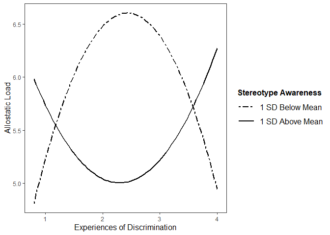

## EOD * CC Interaction on AL

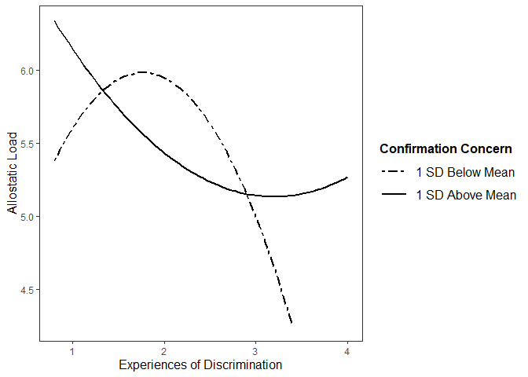

## Plotting ART SA * EOD Interaction on Telomere Length

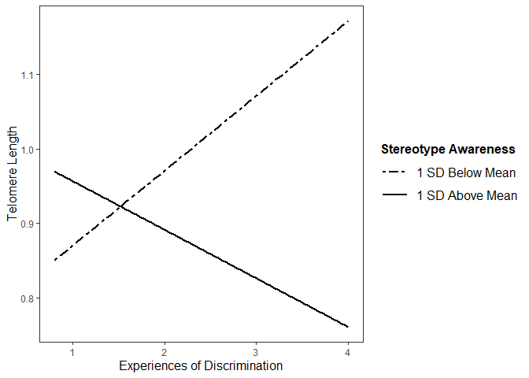